# *Итоговая работа.*

Выполнила:** Абдумаликова Азиза

BDAE201-S1 4-курс МЭО

#### **Предмет:** *Big Data Analysis*

#### **Тема:** *“Кластерный анализ экономических характеристик стран Евросоюза в контексте развития интеграционных процессов”*

```r
library(plm)
```

```r
library(corrplot)
library(psych)
library(smooth)
library(readxl)  # для чтения данных из таблицы Эксель
library(dplyr)   # для удобства работы с таблицами
library(factoextra) # метод каменистой осыпи
library(NbClust)   # для выбора оптим. кол-ва кластеров
library(rgl)   #  3D графики
library(scatterplot3d) # 3D графики
library (cluster) # кластерный анализ
library(readr)
```

# 1. *Аннотация*

Целью данного исследования является анализ и классификация стран Европейского Союза по экономическим показателям с использованием методов кластерного анализа. Исследование направлено на выявление групп стран с схожими экономическими характеристиками на основе таких показателей, как ВВП по паритету покупательной способности, темпы роста ВВП, уровень безработицы, инфляция, рост цен и чистый приток прямых иностранных инвестиций. Работа включает предварительную обработку данных, выбор метода кластеризации, определение оптимального количества кластеров и интерпретацию результатов кластеризации. Основная задача исследования состоит в том, чтобы определить, какие страны Евросоюза являются более похожими друг на друга с точки зрения этих экономических показателей, и как сформированные кластеры могут быть интерпретированы в контексте разработки экономических стратегий. Данный подход может способствовать более целенаправленной разработке экономической политики и стратегий развития как на уровне отдельных стран, так и на уровне всего Евросоюза.

## *Ключевые слова*

Евросоюз, Экономические показатели, Кластерный анализ, ВВП по паритету покупательной способности, Темпы роста ВВП, Уровень безработицы, Инфляция, Рост цен, Чистый приток прямых иностранных инвестиций, Классификация стран, Экономическая гомогенность, Экономическая гетерогенность, Макроэкономическая политика, Стратегии развития.

## *Введение*

В условиях глобализации и интеграционных процессов внутри Европейского Союза (ЕС) вопросы экономической гомогенности и гетерогенности стран-членов приобретают особую актуальность. Понимание экономического разнообразия внутри ЕС необходимо для разработки эффективных макроэкономических политик и стратегий, способствующих устойчивому развитию и снижению экономических дисбалансов. В этом контексте, исследование, направленное на кластеризацию стран ЕС по ключевым экономическим показателям, представляет собой актуальную и значимую задачу.

Цель данного исследования заключается в применении методов кластерного анализа для классификации стран Евросоюза на основе выбранных экономических показателей. Основываясь на анализе ВВП по паритету покупательной способности, темпов роста ВВП, уровня безработицы, инфляции, роста цен и чистого притока прямых иностранных инвестиций, исследование направлено на выявление групп стран с схожими экономическими характеристиками. Это позволит не только лучше понять экономическое положение стран внутри ЕС, но и способствовать формированию более адаптированных экономических политик и стратегий на уровне Евросоюза.

Исследование структурировано следующим образом: после введения проводится предварительная обработка и анализ данных, затем выбирается метод кластеризации и определяется оптимальное количество кластеров. Далее осуществляется сама кластеризация и анализ полученных результатов, что позволяет сформулировать выводы о сходстве и различии экономических характеристик стран ЕС. Завершается исследование формулировкой выводов и рекомендаций, которые могут быть использованы для разработки экономических стратегий и политик.

# 2. *Литературный обзор*

#### *Кластерный анализ* —

это статистический метод, используемый для группировки объектов на основе их сходства. Этот метод широко применяется в различных областях, включая экономику, социологию и биологию, для классификации и анализа гетерогенных данных (Jain, Murty, & Flynn, 1999). В экономических исследованиях кластерный анализ часто используется для изучения экономической гомогенности или гетерогенности групп стран или регионов (Kaufman & Rousseeuw, 2009).

### Предыдущие исследования по кластеризации стран

Множество исследований было посвящено кластеризации стран на основе различных экономических показателей. Например, работы, такие как Sapir (2001), предложили классификацию европейских стран с учетом их экономической интеграции и сходства в экономических показателях. Другие исследования, например, работы Alesina и Spolaore (2003), рассматривают кластеризацию с точки зрения политической экономии и культурных различий. Эти исследования подчеркивают важность комплексного подхода к анализу экономических показателей для понимания межстрановых различий.

### Методологии кластерного анализа

Выбор метода кластеризации играет ключевую роль в исследованиях. Метод k-средних является одним из наиболее популярных из-за его простоты и эффективности в обработке больших наборов данных (MacQueen, 1967). Иерархическая кластеризация также часто используется для исследования экономических данных, поскольку она позволяет визуализировать сходства между объектами на различных уровнях агрегации (Romesburg, 1984). Для определения оптимального числа кластеров исследователи часто используют метод локтя и силуэтный анализ, что позволяет оценить качество кластеризации (Rousseeuw, 1987).

#### **Результаты**

Результаты кластеризации k-средних выявили три группы стран с различными экономическими профилями:

- **Кластер 1** включает страны с высокими темпами роста ВВП и значительной инфляцией, что указывает на быстроразвивающиеся экономики с потенциальными рисками нагревания.
- **Кластер 2** состоит из экономически сильных стран с высоким ВВП по ППС и значительным притоком прямых иностранных инвестиций, что подчеркивает их привлекательность для иностранных инвесторов и экономическую мощь.
- **Кластер 3** объединяет страны с умеренными экономическими показателями, которые могут отражать более стабильный, но менее динамичный экономический рост.

#### **Заключение**

Литературный обзор показывает, что кластерный анализ является мощным инструментом для классификации стран по экономическим показателям. Предыдущие исследования подчеркивают значимость этого подхода для понимания экономической гомогенности или гетерогенности в рамках Евросоюза. Наше исследование демонстрирует, как различные экономические показатели могут быть использованы для классификации стран Евросоюза в группы с схожими экономическими профилями. Это может служить полезным инструментом для анализа экономических стратегий и принятия решений на уровне Европейского союза, а также для дальнейшего исследования экономического развития и интеграции в ЕС. Использование данных Всемирного банка в качестве источника для анализа позволяет получить глубокое понимание текущего экономического состояния стран-членов Евросоюза.

# 3. *Теоретическая часть*

### *Кластеризация k-средних*

— это метод векторной квантизации, используемый в статистике для разбиения n наблюдений на k класстеров, при этом каждое наблюдение относится к класстеру с ближайшим средним. Этот метод часто используется в области обработки данных для группировки аналогичных данных в кластеры.

### *Процесс анализа k-средних включает в себя следующие шаги:*

#### 1. **Инициализация центроидов**:

Сначала выбираются k случайных точек в пространстве данных в качестве начальных центроидов для кластеров. Конечно, вот более подробное объяснение алгоритма k-средних с формулами:

Пусть $X = \{x_1, x_2, ..., x_n\}$ - набор данных, где каждый $x_i$ представляет собой точку в пространстве признаков.

Выбираем k случайных точек $c_1, c_2, ..., c_k$ в качестве начальных центроидов кластеров.

#### 2. **Назначение точек к ближайшим центроидам**:

Каждая точка данных присваивается к кластеру, центроид которого находится ближе всего к данной точке. Это обычно осуществляется на основе евклидового расстояния.

Каждая точка $x_i$ назначается к ближайшему центроиду $c_j$ на основе минимизации расстояния. Обычно используется евклидово расстояние:
$$d(x_i, c_j) = \sqrt{\sum_{l=1}^{m}(x_{il} -
c_{jl})^2}$$

Где $m$ - количество признаков.

#### 3. **Пересчет центроидов**:

После назначения каждой точки кластеру, центроид каждого кластера пересчитывается как среднее значение всех точек, принадлежащих этому кластеру.

После назначения точек кластерам, центроид каждого кластера пересчитывается как среднее значение всех точек, принадлежащих этому кластеру:
$$c_j = \frac{1}{|S_j|}\sum_{x_i
\in S_j} x_i$$

Где $S_j$ - множество точек, принадлежащих кластеру $j$.

#### 4. **Повторение шагов 2 и 3**:

Процесс назначения точек к кластерам и пересчета центроидов повторяется до тех пор, пока центроиды не перестанут значительно изменяться или не будет достигнуто максимальное количество итераций.

#### 5. **Оценка качества кластеризации**:

После завершения процесса кластеризации проводится анализ, чтобы оценить качество полученных кластеров. Это может включать в себя визуализацию кластеров, анализ внутрикластерной и межкластерной дисперсии и другие метрики качества.

Алгоритм k-средних (k-means) имеет несколько преимуществ и особенностей, которые делают его одним из самых популярных методов кластеризации данных:

### *Преимущества:*

1. **Простота и эффективность**: K-средние относительно просты в понимании и реализации. Этот алгоритм обычно хорошо работает на практике для многих типов данных.
2. **Масштабируемость**: Алгоритм k-средних масштабируется на большие объемы данных. Он может быть эффективно применен к наборам данных с большим количеством объектов и признаков.
3. **Интерпретируемость**: Результаты кластеризации k-средних легко интерпретировать. Каждый кластер представляет собой группу объектов с сходными характеристиками, что облегчает анализ и понимание данных.
4. **Универсальность**: K-средние могут быть использованы для различных типов данных и задач, включая текстовые данные, изображения, числовые данные и многое другое.

### *Особенности:*

1. **Чувствительность к начальным условиям**: Результаты кластеризации могут сильно зависеть от начального выбора центроидов. Плохой выбор начальных центроидов может привести к плохому качеству кластеризации.
2. **Необходимость выбора количества кластеров**: Не всегда легко определить оптимальное количество кластеров $k$. Неверно выбранный $k$ может привести к неправильному разделению данных или потере интерпретируемости результатов.
3. **Чувствительность к выбросам**: K-средние чувствительны к выбросам в данных. Одиночные точки или аномалии могут искажать результаты кластеризации, особенно при использовании евклидового расстояния.
4. **Начальная инициализация центроидов**: Выбор начальных центроидов может оказать существенное влияние на качество кластеризации. Различные стратегии инициализации могут привести к разным результатам.

*Пример кода*

```r
# Создаем набор данных
set.seed(123) # Для воспроизводимости результатов
data <- matrix(rnorm(100*2), ncol=2) # 100 наблюдений и 2 признака

# Применяем кластеризацию k-средних
k <- 3 # Количество кластеров
kmeans_result <- kmeans(data, centers=k)

# Просмотрим результаты
print(kmeans_result)
```

```
## K-means clustering with 3 clusters of sizes 38, 29, 33
##
## Cluster means:
##          [,1]       [,2]
## 1 -0.66333772 -0.6219885
## 2 -0.02025692  1.0093022
## 3  1.05560227 -0.4966328
##
## Clustering vector:
##   [1] 1 2 3 1 1 3 3 1 1 2 3 2 3 1 2 3 3 1 3 1 1 1 1 1 2 1 3 2 1 3 2 2 3 3 3 2 3
##  [38] 2 2 1 2 1 1 3 3 1 1 2 2 1 2 2 2 3 1 3 1 3 2 3 2 1 1 2 1 2 2 1 3 3 1 1 3 2
##  [75] 1 3 1 1 2 1 1 2 1 3 1 3 2 3 2 3 3 3 2 1 3 2 3 3 1 1
##
## Within cluster sum of squares by cluster:
## [1] 23.92627 22.26036 24.96196
##  (between_SS / total_SS =  59.4 %)
##
## Available components:
##
## [1] "cluster"      "centers"      "totss"        "withinss"     "tot.withinss"
## [6] "betweenss"    "size"         "iter"         "ifault"
```

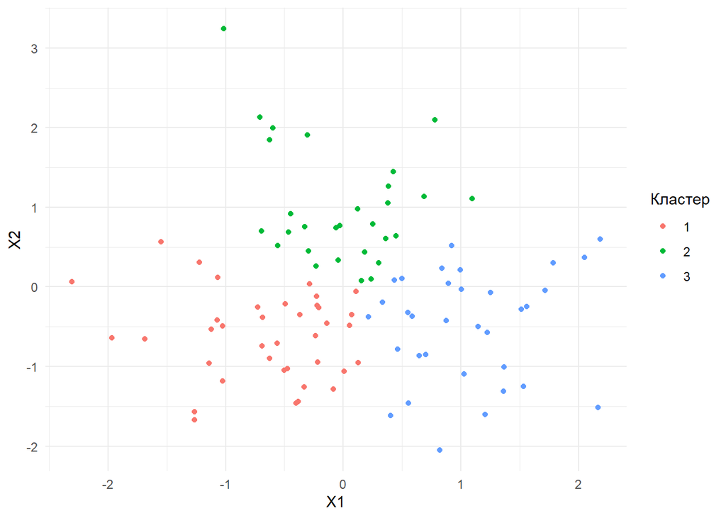

```r
data.frame(data) %>%
  ggplot(aes(x=X1, y=X2, color=factor(kmeans_result$cluster))) +
  geom_point() +
  labs(color='Кластер') +
  theme_minimal()
```

В этом примере мы сначала генерируем набор данных, состоящий из 100 точек с двумя признаками. Затем мы используем функцию kmeans для кластеризации данных на 3 кластера. Наконец, мы используем ggplot2 для визуализации результатов, чтобы увидеть, как данные были сгруппированы.

# 4. *База данных*

```r
library(readxl)
EU <- read_excel("EU.xlsx")
d_tab <- data.frame(EU)
d_tab <- na.omit(d_tab) # удаление пропусков
```

```r
# Установка столбца 'Сountry' в качестве названий строк для d_tab
rownames(d_tab) <- d_tab$Сountry
d_tab <- d_tab[, -which(names(d_tab) == "Сountry")]

head(d_tab)
```

```
##                GDP..PPP. GDP.growth Unemployment.... Inflation.... Price.growth
## Austria            48451        3.2              4.3           2.1          5.1
## Belgium            52213        3.3              5.1           2.6          6.6
## Bulgaria           24544        3.6              4.7          10.4         14.9
## Croatia            29933        3.7              7.2           2.3          5.3
## Cyprus             37289        3.5              4.0           2.5          6.5
## Czech Republic     44360        3.8              2.3           2.7          6.7
##                FDI.net.inflow....
## Austria                       2.4
## Belgium                       3.4
## Bulgaria                      3.3
## Croatia                       2.4
## Cyprus                        4.1
## Czech Republic                3.0
```

```r
dim(d_tab) # количество наблюдений(стран) и переменных
```

```
## [1] 24  6
```

```r
#Стандартизация данных
df <- scale(d_tab)
head(df)
```

```
##                 GDP..PPP.  GDP.growth Unemployment.... Inflation....
## Austria         0.1721793 -0.75828754      -0.31906484    -0.5889072
## Belgium         0.3700199 -0.59864806       0.05221061    -0.3039521
## Bulgaria       -1.0850712 -0.11972961      -0.13342712     4.1413472
## Croatia        -0.8016679  0.03990987       1.02680868    -0.4749251
## Cyprus         -0.4148216 -0.27936910      -0.45829314    -0.3609431
## Czech Republic -0.0429632  0.19954935      -1.24725348    -0.2469611
##                Price.growth FDI.net.inflow....
## Austria          -0.8934688        -0.65423339
## Belgium          -0.2967178        -0.06615843
## Bulgaria          3.0053040        -0.12496593
## Croatia          -0.8139020        -0.65423339
## Cyprus           -0.3365012         0.34549404
## Czech Republic   -0.2569344        -0.30138842
```

#### Данные были взяты из Всемирного банка, что гарантирует их надежность и актуальность для проведения кластерного анализа. Размерность базы данных (24 строки и 6 столбцов) подтверждает, что анализ будет проведен на основе информации о 24 странах Евросоюза по 6 экономическим показателям. Эта база данных обеспечивает твердую основу для глубокого исследования экономических условий и характеристик стран ЕС с целью выявления сходств и различий между ними через процесс кластеризации.

# 5. *Структура данных*

```r
names(d_tab)
```

```
## [1] "GDP..PPP."          "GDP.growth"         "Unemployment...."
## [4] "Inflation...."      "Price.growth"       "FDI.net.inflow...."
```

```r
str(d_tab)
```

```
## 'data.frame':    24 obs. of  6 variables:
##  $ GDP..PPP.         : num  48451 52213 24544 29933 37289 ...
##  $ GDP.growth        : num  3.2 3.3 3.6 3.7 3.5 3.8 2.9 4.4 2.8 3 ...
##  $ Unemployment....  : num  4.3 5.1 4.7 7.2 4 2.3 3.4 5.2 4 6.3 ...
##  $ Inflation....     : num  2.1 2.6 10.4 2.3 2.5 2.7 1.8 4.1 1.9 2.6 ...
##  $ Price.growth      : num  5.1 6.6 14.9 5.3 6.5 6.7 4.8 10.1 4.9 6.6 ...
##  $ FDI.net.inflow....: num  2.4 3.4 3.3 2.4 4.1 3 3.4 4 2.1 1.6 ...
```

```r
str(df)
```

```
##  num [1:24, 1:6] 0.172 0.37 -1.085 -0.802 -0.415 ...
##  - attr(*, "dimnames")=List of 2
##   ..$ : chr [1:24] "Austria" "Belgium" "Bulgaria" "Croatia" ...
##   ..$ : chr [1:6] "GDP..PPP." "GDP.growth" "Unemployment...." "Inflation...." ...
##  - attr(*, "scaled:center")= Named num [1:6] 45176.96 3.67 4.99 3.13 7.35 ...
##   ..- attr(*, "names")= chr [1:6] "GDP..PPP." "GDP.growth" "Unemployment...." "Inflation...." ...
##  - attr(*, "scaled:scale")= Named num [1:6] 1.90e+04 6.26e-01 2.15 1.75 2.51 ...
##   ..- attr(*, "names")= chr [1:6] "GDP..PPP." "GDP.growth" "Unemployment...." "Inflation...." ...
```

##### Данные представлены в формате таблицы, включающей 24 наблюдения, соответствующие различным странам ЕС, и охватывающей 6 ключевых экономических переменных. Структура данных представлена следующим образом:

- **GDP (PPP):** Валовой внутренний продукт по паритету покупательной способности на душу населения, выраженный в долларах. Этот показатель используется для сравнения экономического уровня и жизненного стандарта между странами.
- **GDP growth:** Рост ВВП, выраженный в процентах, показывает динамику экономического развития страны за определенный период.
- **Unemployment %:** Уровень безработицы, выраженный в процентах от общей рабочей силы, указывает на долю населения, активно ищущего работу, но не имеющего её.
- **Inflation %:** Уровень инфляции, выраженный в процентах, отражает общий рост цен на товары и услуги в стране за определенный временной промежуток.
- **Price growth:** Рост цен, также выраженный в процентах, может отражать изменение стоимости жизни или изменение цен на конкретные товары и услуги.
- **FDI net inflow %:** Чистый приток прямых иностранных инвестиций, выраженный в процентах от ВВП, показывает долю инвестиций, поступивших из-за рубежа в экономику страны, относительно её общего экономического объема.

# 6. *Описательная статистика. Визуализация*

```r
summary(d_tab)
```

```
##    GDP..PPP.        GDP.growth    Unemployment.... Inflation....
##  Min.   : 24544   Min.   :2.800   Min.   : 2.300   Min.   : 1.800
##  1st Qu.: 34092   1st Qu.:3.150   1st Qu.: 3.675   1st Qu.: 2.275
##  Median : 39267   Median :3.650   Median : 4.550   Median : 2.600
##  Mean   : 45177   Mean   :3.675   Mean   : 4.987   Mean   : 3.133
##  3rd Qu.: 49649   3rd Qu.:4.050   3rd Qu.: 6.000   3rd Qu.: 3.300
##  Max.   :114115   Max.   :4.900   Max.   :12.300   Max.   :10.400
##   Price.growth    FDI.net.inflow....
##  Min.   : 4.800   Min.   : 1.200
##  1st Qu.: 5.275   1st Qu.: 2.725
##  Median : 6.600   Median : 3.400
##  Mean   : 7.346   Mean   : 3.513
##  3rd Qu.: 8.550   3rd Qu.: 4.025
##  Max.   :14.900   Max.   :10.400
```

### **ВВП по паритету покупательной способности (GDP (PPP)):**

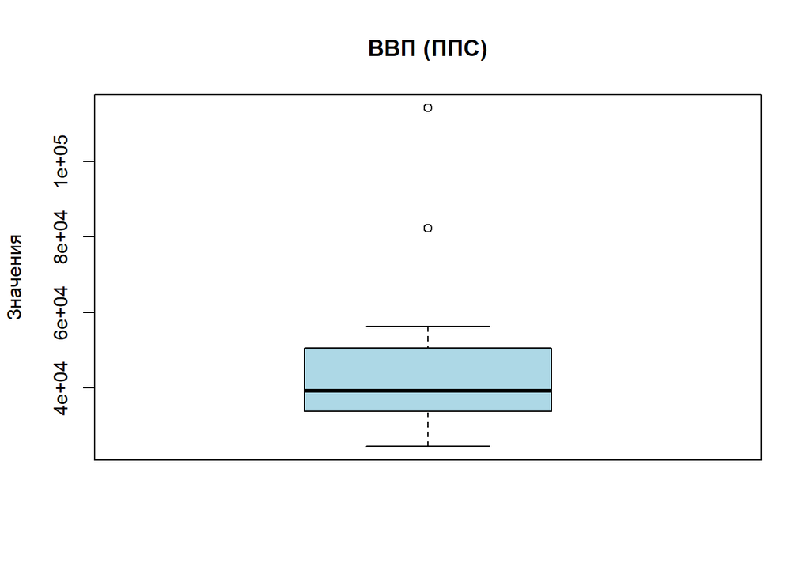

```r
boxplot(d_tab$GDP..PPP., main = "ВВП (ППС)", ylab = "Значения", col = "lightblue")
```

```r
describe(d_tab$GDP..PPP.)
```

```
##    vars  n     mean      sd median  trimmed      mad   min    max range skew
## X1    1 24 45176.96 19015.3  39267 41667.15 10158.03 24544 114115 89571 2.16
##    kurtosis      se
## X1     4.94 3881.48
```

### **Рост ВВП (GDP growth):**

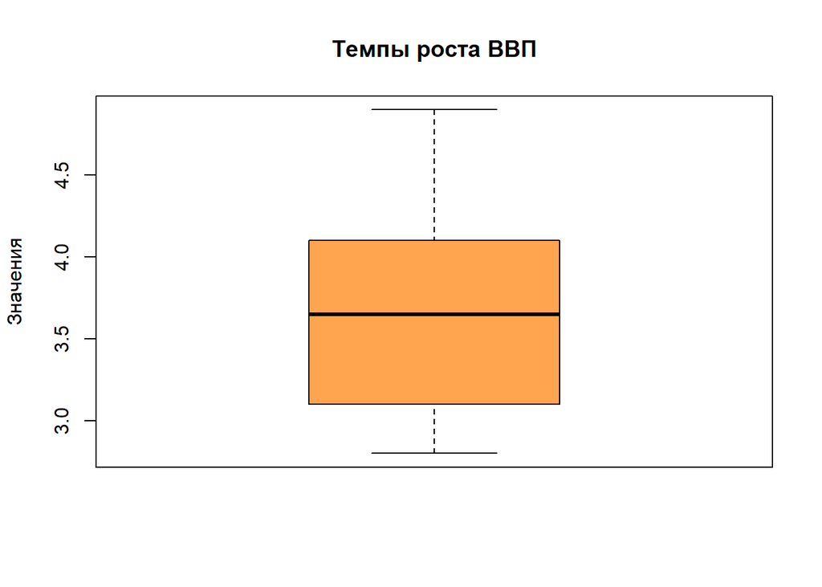

```r
boxplot(d_tab$GDP.growth, main = "Темпы роста ВВП", ylab = "Значения", col = "tan1")
```

```r
describe(d_tab$GDP.growth)
```

```
##    vars  n mean   sd median trimmed  mad min max range skew kurtosis   se
## X1    1 24 3.67 0.63   3.65    3.64 0.74 2.8 4.9   2.1 0.24    -1.09 0.13
```

##### Рост ВВП показывает умеренную изменчивость среди стран с средним значением в 3.67% и стандартным отклонением 0.63%. Разброс значений от 2.8% до 4.9% указывает на относительно стабильный экономический рост в рассматриваемом периоде. Медианное значение (3.65%) близко к среднему, что свидетельствует о симметричности распределения с незначительной асимметрией.

### **Уровень безработицы (Unemployment %):**

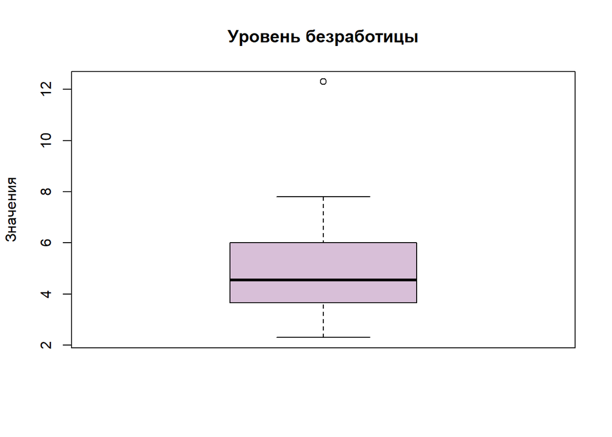

```r
boxplot(d_tab$Unemployment...., main = "Уровень безработицы", ylab = "Значения", col = "thistle")
```

```r
describe(d_tab$Unemployment....)
```

```
##    vars  n mean   sd median trimmed  mad min  max range skew kurtosis   se
## X1    1 24 4.99 2.15   4.55    4.75 1.78 2.3 12.3    10 1.49     3.03 0.44
```

##### Уровень безработицы варьируется существенно среди стран ЕС, от 2.3% до 12.3%, с средним значением в 4.99% и медианой 4.55%. Данные имеют положительную асимметрию (1.49) и относительно высокий коэффициент эксцесса (3.03), что указывает на наличие стран с высоким уровнем безработицы по сравнению с большинством других стран.

### **Уровень инфляции (Inflation %):**

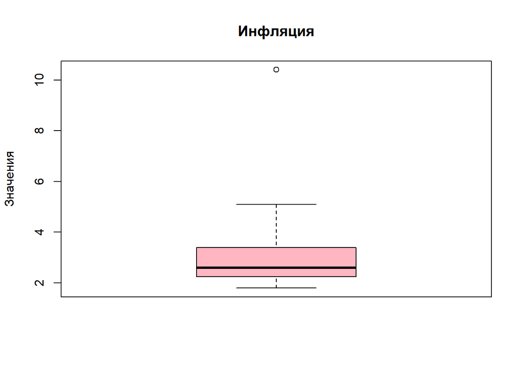

```r
boxplot(d_tab$Inflation...., main = "Инфляция", ylab = "Значения", col = "lightpink")
```

```r
describe(d_tab$Inflation....)
```

```
##    vars  n mean   sd median trimmed  mad min  max range skew kurtosis   se
## X1    1 24 3.13 1.75    2.6     2.8 0.59 1.8 10.4   8.6 2.96     9.38 0.36
```

##### Инфляция демонстрирует значительный разброс значений от 1.8% до 10.4%, с средним 3.13% и медианой 2.6%. Высокие значения асимметрии (2.96) и эксцесса (9.38) подчеркивают неравномерность распределения и наличие стран с аномально высокой инфляцией.

### **Рост цен (Price growth):**

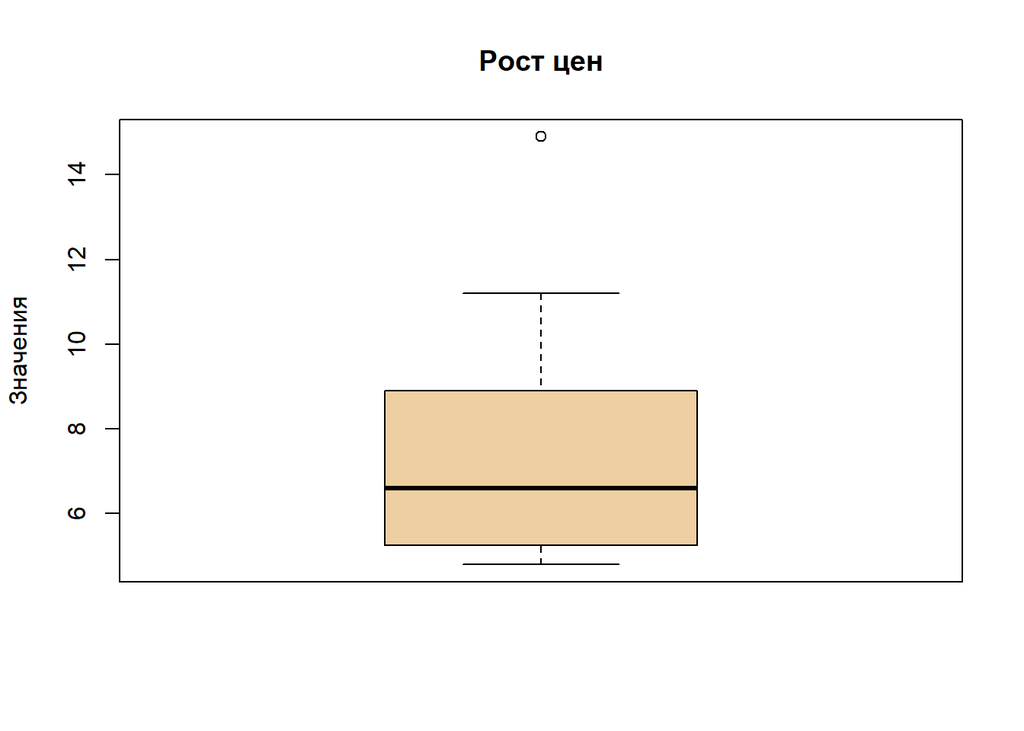

```r
boxplot(d_tab$Price.growth, main = "Рост цен", ylab = "Значения", col = "navajowhite2")
```

```r
describe(d_tab$Price.growth)
```

```
##    vars  n mean   sd median trimmed  mad min  max range skew kurtosis   se
## X1    1 24 7.35 2.51    6.6    7.02 2.08 4.8 14.9  10.1 1.23     1.06 0.51
```

##### Средний рост цен составляет 7.35% с размахом от 4.8% до 14.9%. Эти данные также имеют положительную асимметрию (1.23) и умеренный эксцесс (1.06), что говорит о разнообразии изменений стоимости жизни между странами.

### **Чистый приток прямых иностранных инвестиций (FDI net inflow %):**

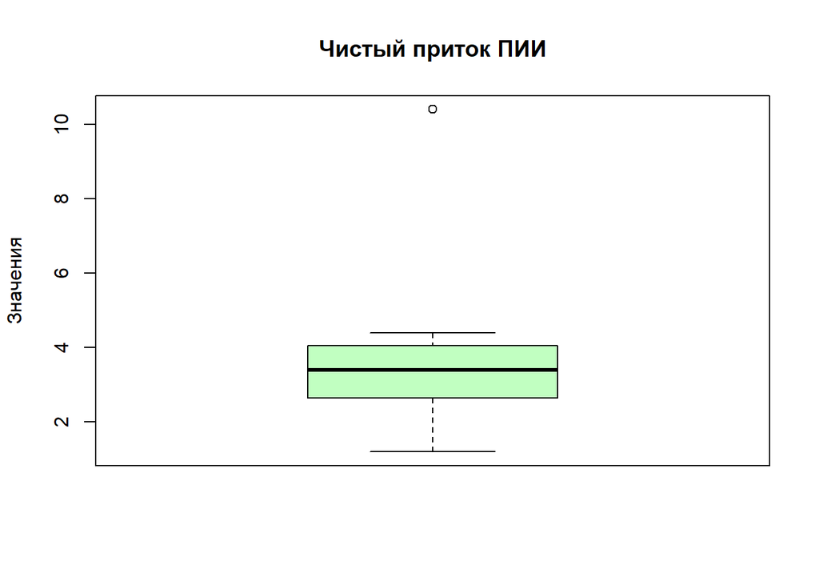

```r
boxplot(d_tab$FDI.net.inflow...., main = "Чистый приток ПИИ", ylab = "Значения", col = "darkseagreen1")
```

```r
describe(d_tab$FDI.net.inflow....)
```

```
##    vars  n mean  sd median trimmed  mad min  max range skew kurtosis   se
## X1    1 24 3.51 1.7    3.4    3.34 0.96 1.2 10.4   9.2 2.56     8.48 0.35
```

##### Среднее значение чистого притока прямых иностранных инвестиций составляет 3.51% с разбросом от 1.2% до 10.4%. Данные выделяются высокой асимметрией (2.56) и коэффициентом эксцесса (8.48), что указывает на значительные различия в привлекательности стран ЕС для иностранных инвесторов.

### *Общее заключение по переменным:*

##### Анализ показателей экономических переменных стран Евросоюза выявил значительные различия в уровне и динамике экономического развития. Наблюдается разнообразие в экономических условиях, отраженное в значительном разбросе значений ВВП по ППС, уровнях безработицы, инфляции, роста цен и притоке прямых иностранных инвестиций. Это подчеркивает важность учета экономических характеристик при формулировании региональной политики и стратегий развития.

# 7. *Анализ взаимосвязей между данными*

```r
cor(d_tab)
```

```
##                      GDP..PPP.  GDP.growth Unemployment.... Inflation....
## GDP..PPP.           1.00000000 -0.07124785     -0.143138953   -0.41472170
## GDP.growth         -0.07124785  1.00000000     -0.153248956    0.26977596
## Unemployment....   -0.14313895 -0.15324896      1.000000000   -0.05680830
## Inflation....      -0.41472170  0.26977596     -0.056808296    1.00000000
## Price.growth       -0.53412465  0.43676936     -0.003341446    0.91887926
## FDI.net.inflow....  0.47791151  0.53501386     -0.167862015   -0.09427912
##                    Price.growth FDI.net.inflow....
## GDP..PPP.          -0.534124655         0.47791151
## GDP.growth          0.436769361         0.53501386
## Unemployment....   -0.003341446        -0.16786201
## Inflation....       0.918879257        -0.09427912
## Price.growth        1.000000000        -0.15333031
## FDI.net.inflow.... -0.153330307         1.00000000
```

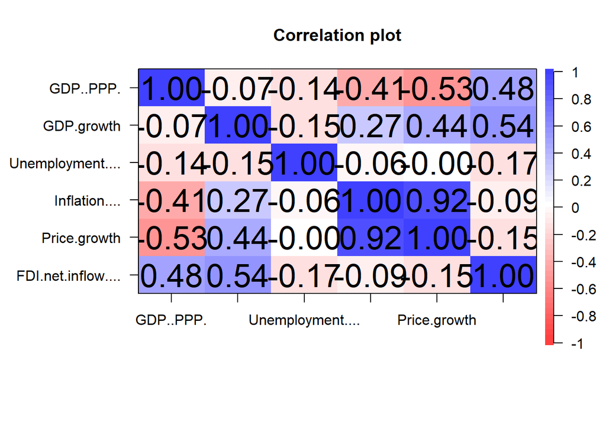

```r
cor.plot(cor(d_tab))
```

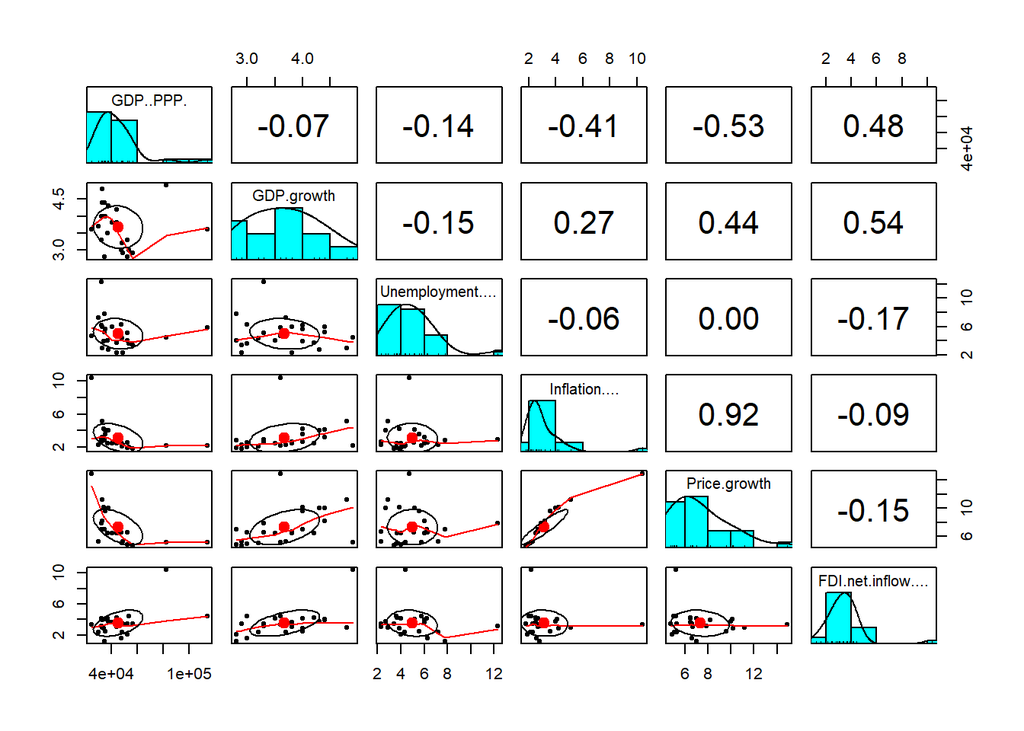

```r
pairs.panels(d_tab)
```

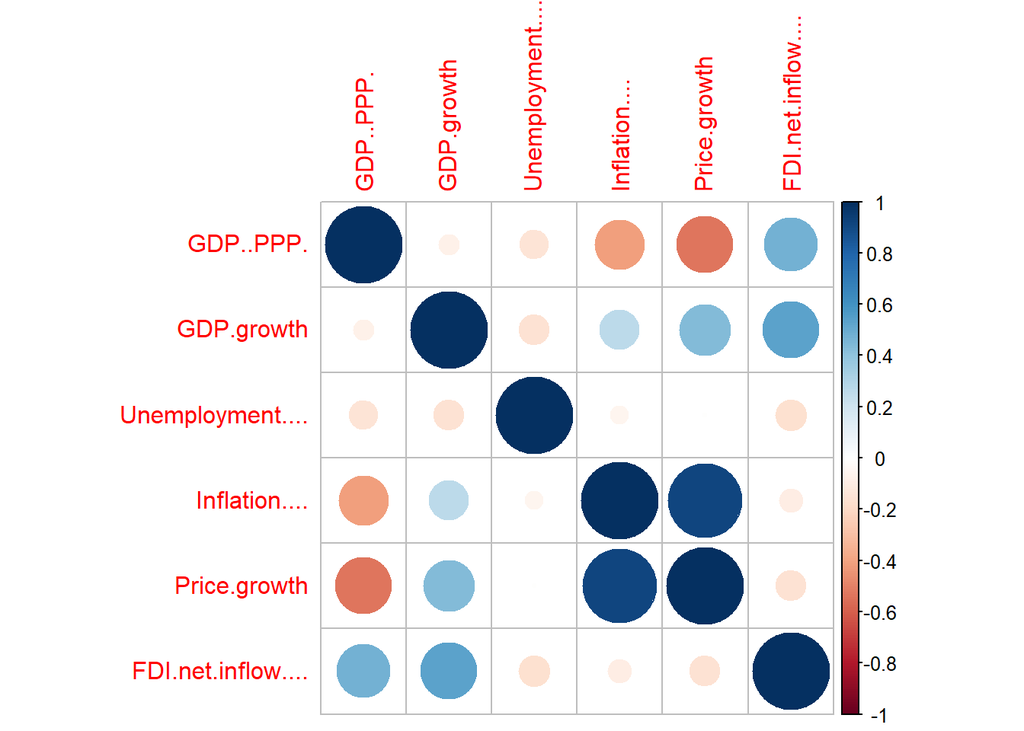

```r
corrplot(cor(d_tab))
```

##### 1. **Инфляция и Рост цен**: Единственная пара переменных с очень высокой положительной корреляцией (0.92), что подтверждает сильную связь между уровнем инфляции и ростом цен. Это указывает на то, что когда цены в стране растут, это обычно сопровождается увеличением инфляции, что логично, учитывая, что оба показателя отражают повышение уровня цен в экономике.

##### 2. Остальные корреляционные коэффициенты не достигают порога 0.75 для классификации как высокой корреляции, но они по-прежнему предоставляют важную информацию о связях между различными экономическими показателями:

- **ВВП (ППС) и Инфляция**: Существует умеренная отрицательная корреляция (-0.41), что может указывать на то, что страны с выше ВВП по ППС склонны иметь более низкую инфляцию.
- **ВВП (ППС) и Рост цен**: Умеренная отрицательная корреляция (-0.53) может свидетельствовать о том, что в странах с более высоким ВВП по ППС цены растут медленнее.
- **GDP рост и Чистый приток ПИИ (FDI)**: Умеренная положительная корреляция (0.54), предполагающая, что страны с более высокими темпами роста ВВП могут привлекать больше ПИИ.
- **ВВП (ППС) и Чистый приток ПИИ**: Умеренная положительная корреляция (0.48) может говорить о том, что более богатые страны привлекают больше ПИИ.

# 8. *Построение модели*

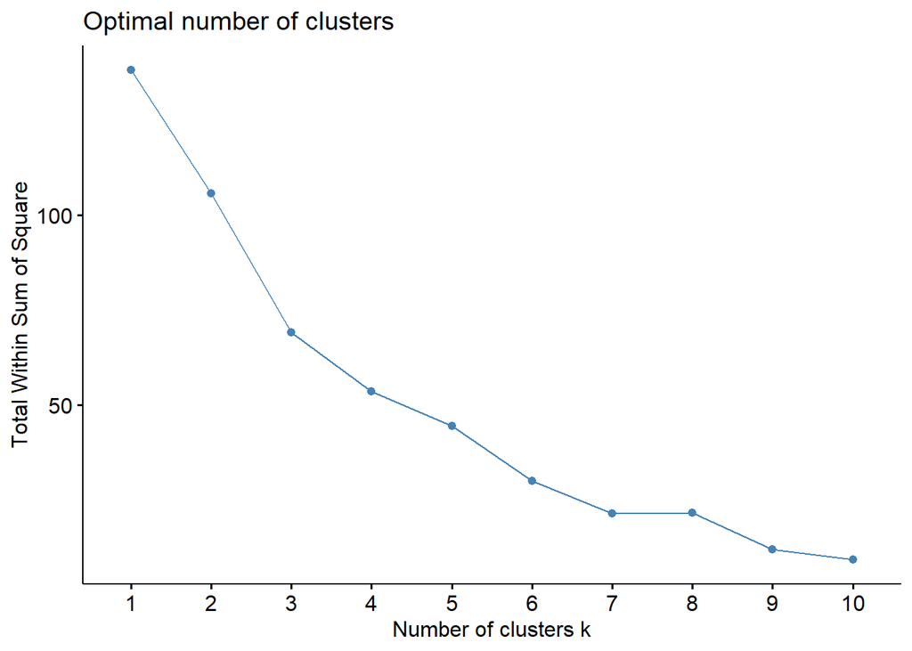

```r
fviz_nbclust(df, kmeans, method="wss")
```

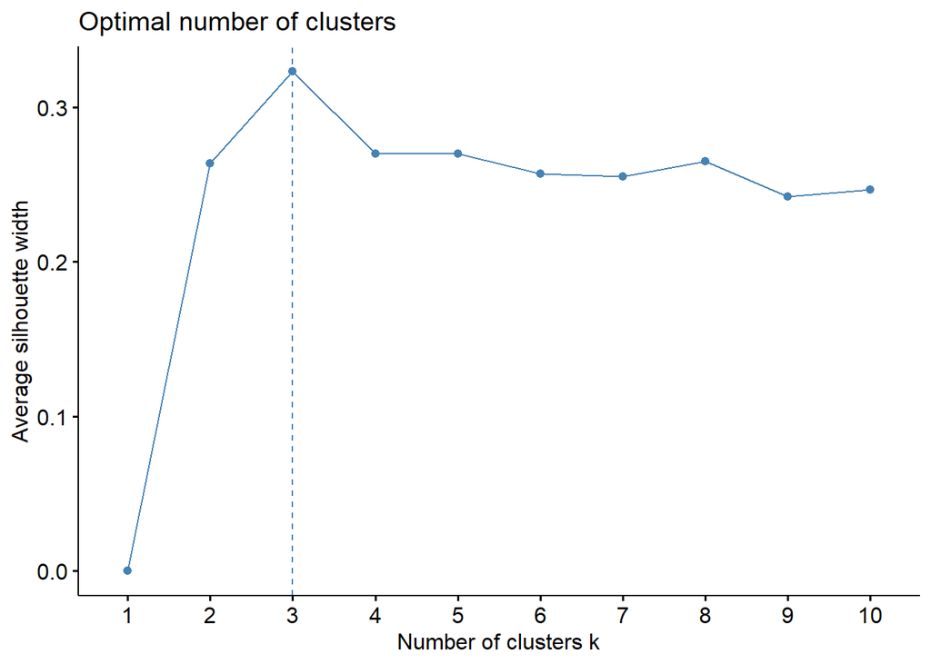

```r
fviz_nbclust(df, kmeans, method="silhouette")
```

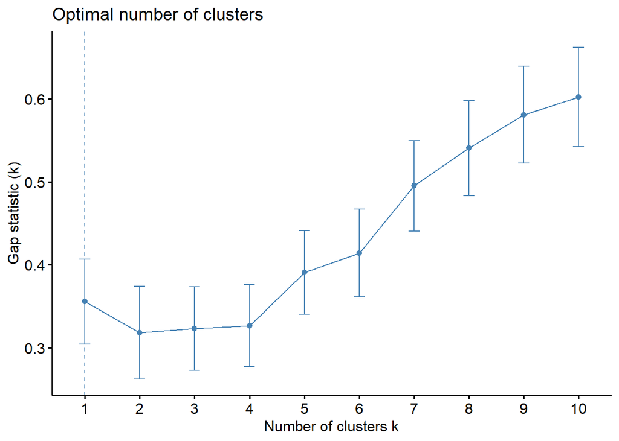

```r
#calculate gap statistic based on number of clusters
gap_stat <- clusGap(df,
 FUN = kmeans,
 nstart = 25,
 K.max = 10,
 B = 50)

#plot number of clusters vs. gap statistic
fviz_gap_stat(gap_stat)
```

```r
#make this example reproducible
set.seed(1)

#perform k-means clustering with k = 4 clusters
km <- kmeans(df, centers = 3, nstart = 25)
km
```

```
## K-means clustering with 3 clusters of sizes 7, 2, 15
##
## Cluster means:
##     GDP..PPP. GDP.growth Unemployment.... Inflation.... Price.growth
## 1 -0.62958092  0.8609129      -0.25939557     1.0312660    1.2946180
## 2  2.78915035  0.9179270       0.05221061    -0.5319161   -0.8536854
## 3 -0.07808228 -0.5241496       0.11408985    -0.4103353   -0.4903303
##   FDI.net.inflow....
## 1         -0.1249659
## 2          2.2861414
## 3         -0.2465014
##
## Clustering vector:
##        Austria        Belgium       Bulgaria        Croatia         Cyprus
##              3              3              1              3              3
## Czech Republic        Denmark        Estonia        Finland         France
##              3              3              1              3              3
##        Germany         Greece        Hungary        Ireland          Italy
##              3              3              1              2              3
##         Latvia      Lithuania     Luxembourg          Malta    Netherlands
##              1              1              2              3              3
##         Poland       Portugal        Romania       Slovakia
##              1              3              1              3
##
## Within cluster sum of squares by cluster:
## [1] 21.568629  9.988137 37.546512
##  (between_SS / total_SS =  49.9 %)
##
## Available components:
##
## [1] "cluster"      "centers"      "totss"        "withinss"     "tot.withinss"
## [6] "betweenss"    "size"         "iter"         "ifault"
```

```r
#view results
km$tot.withinss
```

```
## [1] 69.10328
```

```r
km$centers
```

```
##     GDP..PPP. GDP.growth Unemployment.... Inflation.... Price.growth
## 1 -0.62958092  0.8609129      -0.25939557     1.0312660    1.2946180
## 2  2.78915035  0.9179270       0.05221061    -0.5319161   -0.8536854
## 3 -0.07808228 -0.5241496       0.11408985    -0.4103353   -0.4903303
##   FDI.net.inflow....
## 1         -0.1249659
## 2          2.2861414
## 3         -0.2465014
```

```r
km$totss
```

```
## [1] 138
```

```r
km$withinss
```

```
## [1] 21.568629  9.988137 37.546512
```

```r
km$tot.withinss
```

```
## [1] 69.10328
```

```r
km$betweenss
```

```
## [1] 68.89672
```

```r
km$size
```

```
## [1]  7  2 15
```

```r
km$iter
```

```
## [1] 2
```

```r
km$ifault
```

```
## [1] 0
```

##### **Кластер 1:**

- Болгария
- Эстония
- Венгрия
- Латвия
- Литва
- Польша
- Румыния

##### **Кластер 2:**

- Ирландия
- Люксембург

##### **Кластер 3:**

- Австрия
- Бельгия
- Хорватия
- Кипр
- Чешская Республика
- Дания
- Финляндия
- Франция
- Германия
- Греция
- Италия
- Мальта
- Нидерланды
- Португалия
- Словакия

##### **Кластер 3:** Включает в себя 15 стран с немного ниже средним уровнем ВВП, умеренным ростом, немного выше средним уровнем безработицы и умеренной инфляцией/привлечением иностранных прямых инвестиций.

#### **Ключевые выводы:**

##### 1. **Четкое разделение:** Анализ показывает четкие различия между кластерами в общем экономическом состоянии.

##### 2. **Страны в “трудном” положении:** Кластер 1 включает страны, которые испытывают определенные экономические трудности.

##### 3. **Лидеры:** Кластер 2 содержит страны, которые являются весьма сильными экономическими исполнителями.

##### 4. **“Средний” кластер:** Кластер 3 включает в себя страны с более “средним” экономическим профилем, который находится между кластерами 1 и 2 по многим экономическим показателям.

# 9. *Экономические выводы*

```r
#find means of each cluster указать центры кластеров
mean.km<-aggregate(d_tab, by= list (cluster=km$cluster), mean);mean.km
```

```
##   cluster GDP..PPP. GDP.growth Unemployment.... Inflation.... Price.growth
## 1       1  33205.29   4.214286         4.428571      4.942857    10.600000
## 2       2  98213.50   4.250000         5.100000      2.200000     5.200000
## 3       3  43692.20   3.346667         5.233333      2.413333     6.113333
##   FDI.net.inflow....
## 1           3.300000
## 2           7.400000
## 3           3.093333
```

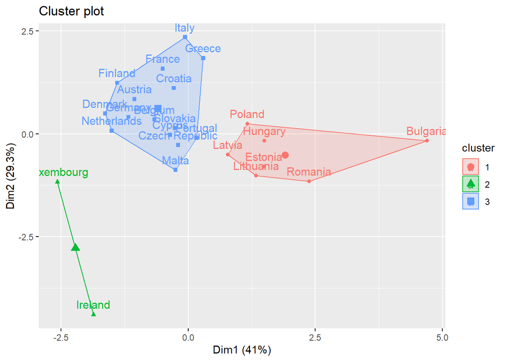

```r
fviz_cluster(km, data = df) # визуализация
```

### *Кластер 2:*

Этот кластер состоит из стран с самым высоким ВВП по ППС (98213.50) и очень высоким чистым притоком прямых иностранных инвестиций (7.400000), но сравнительно низкой инфляцией (2.200000) и умеренным ростом цен (5.200000). Эти страны характеризуются сильной экономикой с устойчивым ростом и привлекательностью для иностранных инвесторов.

#### *Особенности по переменным:*

##### **Рост цен**: Умеренный, что говорит о контроле инфляции.

##### **Чистый приток прямых иностранных инвестиций**: Самый высокий среди всех кластеров, подчеркивает высокую инвестиционную привлекательность этих стран.

### *Кластер 3:*

#### *Особенности по переменным:*

##### **Инфляция и рост цен**: Умеренные, указывающие на относительную ценовую стабильность.

##### **Чистый приток прямых иностранных инвестиций**: Низкий по сравнению с кластером 2, но схож с кластером 1, что может отражать умеренную привлекательность для иностранных инвесторов.

### *Дальнейшие перспективы исследования*

Исследование кластеров стран на основе их экономических показателей представляет собой мощный инструмент для анализа мировой экономики. Кластеризация позволяет выявить общие черты и различия между странами, что может быть полезно для разработки глобальных и региональных экономических стратегий. Основываясь на выявленных кластерах, можно предложить несколько направлений для дальнейших исследований:

1. **Глубинный анализ политик:** Исследование экономических политик и стратегий, которые применяют страны в каждом кластере, может помочь понять, какие меры способствуют ускорению роста ВВП, снижению инфляции и привлечению инвестиций.
2. **Долгосрочное прогнозирование:** Разработка прогностических моделей для предсказания будущего экономического роста стран в каждом кластере. Это может включать анализ трендов и потенциальных рисков, связанных с глобальными экономическими изменениями.
3. **Изучение влияния глобальных событий:** Анализ, как глобальные события, такие как международные конфликты, пандемии или изменение климата, влияют на страны в разных кластерах. Это может помочь выявить уязвимости и определить стратегии устойчивого развития.
4. **Сравнение инвестиционной привлекательности:** Глубокий анализ факторов, влияющих на приток прямых иностранных инвестиций в страны разных кластеров. Можно изучить, как различные аспекты экономической политики, правовой системы и инфраструктуры влияют на инвестиционный климат.
5. **Разработка индивидуальных стратегий развития:** На основе характеристик каждого кластера можно разработать рекомендации по экономическому развитию, которые учитывают специфику и потребности стран этой группы.
6. **Социально-экономический анализ:** Исследование взаимосвязи между экономическими показателями и социальными индикаторами, такими как уровень образования, здравоохранения и жизненного уровня. Это может помочь понять, как экономический рост и инфляция влияют на общественное благосостояние.

Для проведения этих исследований можно использовать различные методы анализа данных, включая кластеризацию, регрессионный анализ, модели машинного обучения и симуляционное моделирование. Это позволит получить глубокое понимание экономических процессов и разработать эффективные стратегии для стимулирования экономического роста и улучшения жизни людей в разных странах.

https://data.worldbank.org/country/EU